# Jointly Defining Cell Types from scRNA-seq and snATAC-seq Data

https://macoskolab.github.io/liger/walkthrough_rna_atac.html

- ここでは10Xが提供する末梢血単核細胞（PBMC）のscRNA-seqとsnATAC-seqデータセットを使用します。
- RNAとATACを共同で解析するためのワークフローは、複数のRNAデータセットを統合するためのワークフローと非常によく似ています。
- 唯一の違いは、(1)ATACデータを遺伝子発現に匹敵する遺伝子レベルの値に加工する必要があることと、(2)RNAデータのみを用いて遺伝子選択を行うことです。

```r
library(liger)
```

## Load Pre-Computed Count Matrices for RNA and ATAC Data

- ATAC-seqは遺伝子発現とは異なるデータモダリティであるクロマチンアクセシビリティを測定するため、RNAデータと統合するために遺伝子レベルの特徴にATACデータを変換する必要がある。
- ATACデータから遺伝子レベルの特徴を計算するための多くの戦略を想像することができますが、我々は、可能な限り最も単純な戦略がうまく機能することを発見しました：各遺伝子の遺伝子本体とプロモーターに重なるリードの数をカウントします。
- cellrangerの出力から始める方法を以下に示しますが、今のところ、RNAとATACデータの最終的な遺伝子×細胞マトリックスを単純に読み込んでいきます。
- These matrices and all other inputs are provided [here](https://umich.box.com/s/5hkhpou4inrulo570yhc38ay8g3ont5b)

```r
rna_clusts = readRDS("rna-atac/rna_cluster_assignments.RDS")
atac_clusts = readRDS("rna-atac/atac_cluster_assignments.RDS")
pbmc.atac <- readRDS('rna-atac/pbmc.atac.expression.mat.RDS')
pbmc.rna <- readRDS('rna-atac/pbmc.rna.expression.mat.RDS')
```

```r
head(pbmc.atac)
```

A matrix: 6 × 8728 of type dbl

|  | AAACGAAAGAGCGAAA-1 | AAACGAAAGAGTTTGA-1 | AAACGAAAGCGAGCTA-1 | AAACGAAAGGCTTCGC-1 | AAACGAAAGTGCTGAG-1 | AAACGAACAAGGGTAC-1 | AAACGAAGTCAGGCTC-1 | AAACGAAGTGCCCGAT-1 | AAACGAAGTTGTATCG-1 | AAACGAATCAGTTGAC-1 | ⋯ | TTTGTGTGTAACCCAT-1 | TTTGTGTGTCGGCTGT-1 | TTTGTGTGTGATGCTT-1 | TTTGTGTGTTTAAGGA-1 | TTTGTGTTCATCGCCT-1 | TTTGTGTTCATGCTTT-1 | TTTGTGTTCCGAGAGA-1 | TTTGTGTTCGAAGCCC-1 | TTTGTGTTCTACTTTG-1 | TTTGTGTTCTTGTGCC-1 |
| --- | --- | --- | --- | --- | --- | --- | --- | --- | --- | --- | --- | --- | --- | --- | --- | --- | --- | --- | --- | --- | --- |
| A1BG | 0 | 0 | 5 | 24 | 1 | 0 | 0 | 3 | 0 | 0 | ⋯ | 0 | 1 | 0 | 0 | 0 | 3 | 2 | 0 | 3 | 0 |
| A1BG-AS1 | 0 | 0 | 0 | 14 | 0 | 0 | 0 | 1 | 0 | 0 | ⋯ | 0 | 1 | 0 | 0 | 0 | 0 | 0 | 0 | 1 | 0 |
| A1CF | 0 | 0 | 0 | 1 | 0 | 2 | 0 | 0 | 0 | 5 | ⋯ | 0 | 0 | 0 | 0 | 0 | 0 | 0 | 0 | 0 | 0 |
| A2M | 0 | 0 | 1 | 3 | 0 | 0 | 0 | 1 | 0 | 0 | ⋯ | 1 | 0 | 0 | 0 | 3 | 0 | 0 | 0 | 0 | 0 |
| A2M-AS1 | 0 | 0 | 0 | 2 | 0 | 0 | 0 | 1 | 0 | 0 | ⋯ | 0 | 0 | 0 | 0 | 0 | 0 | 0 | 0 | 0 | 0 |
| A2ML1 | 0 | 0 | 1 | 0 | 0 | 0 | 0 | 0 | 0 | 0 | ⋯ | 0 | 0 | 0 | 0 | 0 | 0 | 0 | 0 | 0 | 0 |

```r
apply(pbmc.atac, 2, sum)
```

20900

**AAACGAAAGGCTTCGC-1**

165558

**AAACGAAAGTGCTGAG-1**

7679

**AAACGAACAAGGGTAC-1**

79725

**AAACGAAGTCAGGCTC-1**

5078

**AAACGAAGTGCCCGAT-1**

13853

**AAACGAAGTTGTATCG-1**

10529

**AAACGAATCAGTTGAC-1**

7344

**AAACGAATCCTTACGC-1**

8580

**AAACGAATCGTTTGAG-1**

10290

**AAACGAATCTGCCGAG-1**

1937

**AAACTCGAGATGCGCA-1**

16277

**AAACTCGAGCATGATA-1**

5583

**AAACTCGAGCGCATTT-1**

18272

**AAACTCGAGTACTCTG-1**

17727

**AAACTCGAGTCACGCC-1**

8769

**AAACTCGAGTCTCTAG-1**

11273

**AAACTCGCAAAGAGAG-1**

28057

**AAACTCGCAAGCGAAC-1**

7748

**AAACTCGCACTCAGCG-1**

9330

**AAACTCGCACTTGCGG-1**

6017

**AAACTCGCAGCGTCGT-1**

9884

**AAACTCGCATCACAGT-1**

9632

**AAACTCGCATGTGGGA-1**

64622

**AAACTCGGTCAGAAGC-1**

8710

**AAACTCGGTCATAGCT-1**

13180

**AAACTCGGTGGATTCT-1**

10375

**AAACTCGGTTTGATCG-1**

35597

**AAACTCGTCAGGTCTA-1**

34022

**AAACTCGTCCACTAGA-1**

7793

**AAACTCGTCCCAATAG-1**

20309

**AAACTCGTCGATGTAC-1**

10386

**AAACTCGTCTGGCACG-1**

11054

**AAACTCGTCTGGCGCA-1**

8398

**AAACTGCAGAATCAAC-1**

18158

**AAACTGCAGAGTGGAA-1**

6274

**AAACTGCAGCAAGGTC-1**

1411

**AAACTGCAGCTCCATA-1**

8579

**AAACTGCAGTCTGTGT-1**

15090

**AAACTGCCAACAAACA-1**

17164

**AAACTGCCAAGAGATT-1**

6725

**AAACTGCCAAGCCAGA-1**

4461

**AAACTGCCACTTGCGG-1**

2529

**AAACTGCCATGTATCG-1**

19433

**AAACTGCGTACTAGAA-1**

11102

**AAACTGCGTCATAGCT-1**

8138

**AAACTGCGTCATGAGG-1**

10286

**AAACTGCGTCGATTAC-1**

10747

**AAACTGCGTGCATTCA-1**

18968

**AAACTGCGTGCTGAAG-1**

5662

**AAACTGCGTTACCACA-1**

4457

**AAACTGCTCATTCATC-1**

7596

**AAACTGCTCCGTACGG-1**

4430

**AAACTGCTCCTATCCG-1**

8247

**AAACTGCTCGTTCAGA-1**

7537

**AAACTGCTCTGAGTAC-1**

9050

**AAAGATGAGAAGGGCG-1**

14338

**AAAGATGAGCGAGAAA-1**

15897

**AAAGATGAGGCTAAAT-1**

21941

**AAAGATGAGTCCAGAG-1**

27508

**AAAGATGAGTCGACCC-1**

6763

**AAAGATGAGTTATGAG-1**

8424

**AAAGATGCAACCTCTC-1**

6862

**AAAGATGCAAGGTCGA-1**

8268

**AAAGATGCAAGTCTGT-1**

4930

**AAAGATGCACGTTACA-1**

20947

**AAAGATGCAGCAACCC-1**

9906

**AAAGATGCAGCACATT-1**

15625

**AAAGATGCAGCGTCGT-1**

29163

**AAAGATGCATGACTGT-1**

14882

**AAAGATGTCCACACCT-1**

9105

**AAAGATGTCCTGAAAC-1**

11898

**AAAGATGTCGCGGCAT-1**

5458

**AAAGATGTCGCTAGTA-1**

14097

**AAAGATGTCGTCGCAG-1**

34902

**AAAGATGTCTAGCAGT-1**

29682

**AAAGGATAGAACCATA-1**

5936

**AAAGGATAGAGAATTC-1**

2057

**AAAGGATAGAGGAACA-1**

10847

**AAAGGATAGTCTGGGA-1**

4790

**AAAGGATAGTGAGTTA-1**

6448

**AAAGGATCAAGGGAGG-1**

18435

**AAAGGATCACCACCAG-1**

28008

**AAAGGATCACGTTGTA-1**

7929

**AAAGGATCAGATGGCA-1**

23364

**AAAGGATCATGGAGGT-1**

10622

**AAAGGATGTCCCTTTG-1**

4976

**AAAGGATGTCGTAATC-1**

5504

**AAAGGATGTCTAAGAA-1**

19617

**AAAGGATGTCTCAAAC-1**

6224

**AAAGGATGTCTTAGCA-1**

9149

**AAAGGATGTGGACGAT-1**

6701

**AAAGGATTCACTACCC-1**

12604

**AAAGGATTCCAACCTC-1**

7621

**AAAGGATTCCGTCAAA-1**

21632

**AAAGGATTCCTTACGC-1**

30465

**AAAGGATTCTATGAGC-1**

9442

**AAAGGATTCTGAACGT-1**

27261

**AAAGGATTCTGATCCC-1**

6136

**AAAGGGCAGAAGAGTG-1**

34067

**AAAGGGCAGACCTATC-1**

12702

**AAAGGGCAGAGTGGAA-1**

10948

**AAAGGGCAGCCATGGA-1**

1998

**AAAGGGCAGGTAGGAA-1**

6050

**AAAGGGCAGTCTCCAA-1**

4116

**AAAGGGCAGTTCAACC-1**

8627

**AAAGGGCCACGATATC-1**

13002

**AAAGGGCCATTGCCTC-1**

8780

**AAAGGGCGTAGTAACA-1**

14635

**AAAGGGCGTAGTATCC-1**

5137

**AAAGGGCGTCAGTGCC-1**

20213

**AAAGGGCGTCGATAGG-1**

18881

**AAAGGGCGTGAGGTCA-1**

9379

**AAAGGGCGTGCTTGAT-1**

6132

**AAAGGGCGTGGCGCTT-1**

12947

**AAAGGGCGTTAGGAGC-1**

49776

**AAAGGGCGTTTGAAGA-1**

12169

**AAAGGGCTCGGTAGGA-1**

28897

**AAAGGGCTCGGTCGAC-1**

6368

**AAAGGGCTCGTGGGTC-1**

3247

**AAAGGGCTCTAGTCGA-1**

8783

**AAAGGGCTCTGAGTCA-1**

3814

**AAATGAGAGCTGGAGT-1**

24567

**AAATGAGCAAGGCGTA-1**

17491

**AAATGAGCAATCAGGG-1**

10553

**AAATGAGCAGCCACGT-1**

10702

**AAATGAGCATACTGCA-1**

12947

**AAATGAGGTACAAGCG-1**

18042

**AAATGAGGTAGTACAA-1**

21660

**AAATGAGGTCCTCAGG-1**

10445

**AAATGAGGTGTGTGCC-1**

3049

**AAATGAGGTTGTGACT-1**

16467

**AAATGAGTCAGTCTTT-1**

14193

**AAATGAGTCGCACCGA-1**

35347

**AAATGAGTCGCAGATT-1**

11789

**AAATGAGTCGCGTTCT-1**

83551

**AAATGAGTCGGTAGGA-1**

7930

**AAATGAGTCTATATCC-1**

16103

**AAATGAGTCTGGACAT-1**

7487

**AAATGCCAGTGAAACT-1**

8909

**AAATGCCCAACAAACA-1**

12674

**AAATGCCCAAGTTGCT-1**

13303

**AAATGCCCACACATTG-1**

6833

**AAATGCCGTATTTGCG-1**

15817

**AAATGCCGTCCGCTTT-1**

9861

**AAATGCCGTGAATCGG-1**

2639

**AAATGCCGTTACGAAA-1**

12747

**AAATGCCGTTATGCAC-1**

18734

**AAATGCCGTTCGGGAA-1**

2812

**AAATGCCTCAACACGT-1**

10539

**AAATGCCTCTATCTCA-1**

29563

**AAATGCCTCTCGACCT-1**

3488

**AAATGCCTCTCTGCAC-1**

11423

**AACAAAGAGCAATAAC-1**

7834

**AACAAAGAGGCAAGGG-1**

100983

**AACAAAGAGGCACCTC-1**

6495

**AACAAAGAGTCGTATC-1**

12793

**AACAAAGAGTCTCGAT-1**

15690

**AACAAAGAGTGAGTGC-1**

5854

**AACAAAGAGTGATATG-1**

8474

**AACAAAGAGTTGAATG-1**

4250

**AACAAAGCAATAGCGG-1**

3041

**AACAAAGCACCTATTT-1**

18855

**AACAAAGCACGCTCAG-1**

20708

**AACAAAGCAGGGTACA-1**

6333

**AACAAAGCATAGGCGA-1**

10664

**AACAAAGCATCGCCTT-1**

17060

**AACAAAGCATCGTGAT-1**

9845

**AACAAAGCATGATCGT-1**

6557

**AACAAAGGTACGCAAG-1**

15637

**AACAAAGGTCTGGGAA-1**

15492

**AACAAAGGTGCGTGTC-1**

2459

**AACAAAGGTTGCCGCA-1**

2013

**AACAAAGGTTTCGATG-1**

13032

**AACAAAGTCACAAGCT-1**

38696

**AACAAAGTCCGATTGA-1**

33375

**AACAAAGTCGTGGCGT-1**

6560

**AACAGTCAGACACAAT-1**

5976

**AACAGTCAGCACACCC-1**

10138

**AACAGTCAGTCGATAA-1**

17175

**AACAGTCAGTTCAACC-1**

11203

**AACAGTCCAACGAGGT-1**

6752

**AACAGTCCAACGTAGG-1**

8241

**AACAGTCCACCACCAG-1**

68392

**AACAGTCCACTGATTG-1**

7942

**AACAGTCCACTTGCGG-1**

39004

**AACAGTCCATCACAGT-1**

11636

**AACAGTCCATTTGGCA-1**

6700

**AACAGTCGTATCCTTT-1**

14185

**AACAGTCGTGGCCTTG-1**

7074

**AACAGTCTCAGGTTTG-1**

14344

**AACATCGAGAAATCTG-1**

10068

**AACATCGAGACACGGT-1**

8520

**AACATCGAGAGCCTGA-1**

10254

**AACATCGAGCGCGTTC-1**

12587

**AACATCGAGCTATCGT-1**

15105

**AACATCGAGGTGATGC-1**

108126

**AACATCGAGTAATCAG-1**

24654

**AACATCGCAATCACTG-1**

**AACATCGCACGACGAA-1**

7930

**AACATCGCAGCGTGAA-1**

4905

**AACATCGGTCGGCTGT-1**

4550

**AACATCGGTTCTGATG-1**

6998

**AACATCGGTTGCAGAG-1**

12864

**AACATCGGTTGCAGCC-1**

10779

**AACATCGTCCAGGGAA-1**

25515

**AACATCGTCCATACGA-1**

25797

**AACATCGTCCATCTAT-1**

8448

**AACATCGTCCCTACCA-1**

8813

**AACATCGTCCGTTAGA-1**

5623

**AACATCGTCGATCGCG-1**

34037

**AACATCGTCGCGCCAA-1**

26569

**AACATCGTCGTGATAC-1**

10568

**AACATCGTCTCGGCGA-1**

12469

**AACCAACAGACTTCCA-1**

10633

**AACCAACAGGGAAGCG-1**

10162

**AACCAACAGTCACACT-1**

13014

**AACCAACAGTCAGCCC-1**

7054

**AACCAACAGTGATCTC-1**

6619

**AACCAACAGTGTCGGA-1**

5586

**AACCAACCAATGTAAG-1**

5027

**AACCAACCACCCATCT-1**

5476

**AACCAACCACGCTCAG-1**

29524

**AACCAACCACTGTCGG-1**

5966

**AACCAACCAGGGAGTT-1**

14050

**AACCAACCATGATCGT-1**

12231

**AACCAACCATGCGCTG-1**

4199

**AACCAACGTAGAAAGG-1**

5576

**AACCAACTCAACACGT-1**

4706

**AACCAACTCCCACTTG-1**

5484

**AACCAACTCCCGTAGG-1**

7346

**AACCAACTCCTGGAAT-1**

8808

**AACCAACTCTCGACCT-1**

3963

**AACCGATAGAACTCCT-1**

11840

**AACCGATAGCAATGTA-1**

12291

**AACCGATAGCTCCGGT-1**

13578

**AACCGATCAACCTCCT-1**

3209

**AACCGATCACCTGAAT-1**

12503

**AACCGATCACTCGGAC-1**

5735

**AACCGATCAGAAGTGC-1**

1439

**AACCGATCAGCGTGAA-1**

13200

**AACCGATCATCCCAAA-1**

17969

**AACCGATCATGTAGAA-1**

6337

**AACCGATGTCTCTAAG-1**

5621

**AACCGATGTGCGTAGA-1**

15781

**AACCGATTCAAACCCA-1**

73301

**AACCGATTCAGCCGAC-1**

16007

**AACCGATTCATCGCTC-1**

12701

**AACCGATTCCACTAGA-1**

4457

**AACCGATTCCAGTACA-1**

10002

**AACCGATTCCATCTAT-1**

32361

**AACCGATTCCTAAAGC-1**

19688

**AACCGATTCTGTCGTC-1**

8004

**AACCGATTCTTAACGG-1**

18945

**AACCTGAAGAAGACTT-1**

26165

**AACCTGAAGCGTCTGC-1**

5265

**AACCTGAAGGACTAGC-1**

18181

**AACCTGAAGGCACTAG-1**

29608

**AACCTGAAGGCTTTAC-1**

10024

**AACCTGAAGTCTGTGT-1**

20009

**AACCTGAAGTTGACAA-1**

6974

**AACCTGACAAGTAACA-1**

2948

**AACCTGACAGCGTACC-1**

1921

**AACCTGACATATACGC-1**

2169

**AACCTGACATCCCAAA-1**

2566

**AACCTGAGTCATAGCT-1**

18305

**AACCTGAGTCTGATTG-1**

3040

**AACCTGAGTGAATGGC-1**

15019

**AACCTGAGTGTTAGAA-1**

1471

**AACCTGATCAACACGT-1**

5931

**AACCTGATCACAAGCT-1**

9915

**AACCTGATCATCGCTC-1**

8919

**AACCTGATCCCACTTG-1**

6018

**AACCTGATCCGGCGAT-1**

8146

**AACCTGATCGCTAGTA-1**

6823

**AACCTGATCGGATGTT-1**

10068

**AACCTGATCGTGGTAT-1**

8809

**AACCTGATCTCATATC-1**

7087

**AACCTGATCTCCTTGG-1**

8271

**AACCTGATCTCGACAA-1**

8278

**AACCTTTAGACACTTC-1**

23341

**AACCTTTAGTAGACCG-1**

74324

**AACCTTTCAATCCATG-1**

20257

**AACCTTTCACCACAGC-1**

8461

**AACCTTTCACCTATTT-1**

7857

**AACCTTTCAGATACAA-1**

11824

**AACCTTTCATAGCCGC-1**

7605

**AACCTTTCATAGTCCA-1**

4543

**AACCTTTGTAAGGTCG-1**

4286

**AACCTTTGTGAGCTAG-1**

4727

**AACCTTTGTGCAAGAC-1**

5143

**AACCTTTGTTCTTTGT-1**

10887

**AACCTTTTCGCTTGAA-1**

4473

**AACCTTTTCGTTGTTT-1**

5413

**AACCTTTTCTGGACAT-1**

9730

**AACGAGGAGAATGCTA-1**

12209

**AACGAGGAGACCCTAT-1**

6257

**AACGAGGAGCAACGGT-1**

3020

**AACGAGGAGGCTCAGA-1**

8778

**AACGAGGAGTCTAGAA-1**

11582

**AACGAGGCAAGCAGGT-1**

6803

**AACGAGGCAATGTAAG-1**

4464

**AACGAGGCACCCTTTG-1**

8240

**AACGAGGGTACAAGCG-1**

15926

**AACGAGGGTGCATTGT-1**

5892

**AACGAGGGTGCTGTGC-1**

16571

**AACGAGGGTTAGTAGA-1**

3949

**AACGAGGTCAAGAGAT-1**

11131

**AACGAGGTCTGTTTAC-1**

3420

**AACGGGAAGACCGCAA-1**

3620

**AACGGGACAAGTAACA-1**

9598

**AACGGGACAGAGAGAA-1**

8377

**AACGGGACAGGGCTTC-1**

9028

**AACGGGACAGTTAAAG-1**

1779

**AACGGGAGTAAGTCTC-1**

8100

**AACGGGAGTGCCCAGT-1**

19389

**AACGGGAGTGTCGGTC-1**

10936

**AACGGGATCCGGACTG-1**

6084

**AACGGGATCCTTACGC-1**

15881

**AACGGGATCGGGAAAC-1**

39108

**AACGGGATCGTTTGAG-1**

7196

**AACGGGATCTCTATTG-1**

7564

**AACGGGATCTTGTCGC-1**

6005

**AACGTACAGATAGGTT-1**

7851

**AACGTACAGGAAGGTA-1**

6025

**AACGTACAGTACGACG-1**

3596

**AACGTACAGTGATCTC-1**

7922

**AACGTACCAGCAAACG-1**

19048

**AACGTACCATTCGTCC-1**

18588

**AACGTACGTAAACCCT-1**

11004

**AACGTACGTAACATAG-1**

9249

**AACGTACGTACGACCC-1**

23451

**AACGTACGTACTTGAC-1**

5844

**AACGTACGTCTCGGGT-1**

4659

**AACGTACGTGCGCTCA-1**

10495

**AACGTACGTTACTACG-1**

13083

**AACGTACTCCATACGA-1**

8387

**AACGTACTCGTTGTAG-1**

1431

**AACGTACTCTAGCAAC-1**

15093

**AACTGGTAGACGTCAG-1**

10668

**AACTGGTAGCTATCGT-1**

7686

**AACTGGTAGGCTGGAT-1**

16984

**AACTGGTAGTCAGGAC-1**

8381

**AACTGGTAGTCTTAGC-1**

1996

**AACTGGTAGTTGCGCC-1**

17119

**AACTGGTCAACGCAAG-1**

5462

**AACTGGTCAAGAGATT-1**

16303

**AACTGGTCAGACTAAA-1**

6591

**AACTGGTCAGCACATT-1**

12457

**AACTGGTCAGTAACCT-1**

13631

**AACTGGTCATAGAATG-1**

11865

**AACTGGTCATTGATGC-1**

1941

**AACTGGTGTACGAGAC-1**

154601

**AACTGGTGTCGTCGCA-1**

5312

**AACTGGTGTGGTCGAA-1**

14880

**AACTGGTGTGTTAGAA-1**

12265

**AACTGGTGTGTTGTTG-1**

8621

**AACTGGTGTTAGAGAT-1**

7649

**AACTGGTGTTCTACCC-1**

15258

**AACTGGTTCAAATGGA-1**

5466

**AACTGGTTCCTATCCG-1**

9802

**AACTGGTTCGGATAGG-1**

8382

**AACTGGTTCGTCGCAG-1**

2168

**AACTGTGAGATGCGCA-1**

12987

**AACTGTGAGCCGCTGT-1**

7494

**AACTGTGAGTACGCGA-1**

12084

**AACTGTGCAAAGCTTC-1**

15921

**AACTGTGCAAATAGTG-1**

10389

**AACTGTGCAATTCGTG-1**

11594

**AACTGTGCAGAGTCGA-1**

9234

**AACTGTGCATAAAGTG-1**

6836

**AACTGTGCATCATAGC-1**

16269

**AACTGTGCATTTCACT-1**

12163

**AACTGTGGTATCTAGC-1**

4589

**AACTGTGGTCAGACGA-1**

2961

**AACTGTGGTGATAGAT-1**

2457

**AACTGTGGTGCATCAT-1**

5846

**AACTGTGGTGCGTAGA-1**

20919

**AACTGTGGTTATCGAC-1**

10232

**AACTGTGGTTCTTTCA-1**

99733

**AACTGTGTCAAGGCAG-1**

7153

**AACTGTGTCACATTCT-1**

4133

**AACTGTGTCGCTGATA-1**

11644

**AACTGTGTCGCTTCAC-1**

8259

**AACTGTGTCGGCATAT-1**

4358

**AACTGTGTCTCTATCA-1**

19405

**AACTTGGAGAATGCTA-1**

6820

**AACTTGGAGCTAGCAG-1**

13031

**AACTTGGAGGTCGTTT-1**

6414

**AACTTGGAGTCCGTGC-1**

5334

**AACTTGGCAATTCTCT-1**

7670

**AACTTGGCAGCAACGA-1**

8332

**AACTTGGCAGGACCTC-1**

11027

**AACTTGGCAGTAGTTC-1**

7581

**AACTTGGCATTTCTTG-1**

8087

**AACTTGGGTAGCTGTT-1**

8081

**AACTTGGGTAGTATCC-1**

13908

**AACTTGGGTATTCGAC-1**

12475

```r
pbmc.rna[0:10,0:20]
```

```
   [[ suppressing 20 column names ‘pbmc.rna_AAACCCAAGCGCCCAT’, ‘pbmc.rna_AAACCCAAGGTTCCGC’, ‘pbmc.rna_AAACCCACAGAGTTGG’ ... ]]
```

```
10 x 20 sparse Matrix of class "dgCMatrix"

MIR1302-2HG . . . . . . . . . . . . . . . . . . . .
FAM138A     . . . . . . . . . . . . . . . . . . . .
OR4F5       . . . . . . . . . . . . . . . . . . . .
AL627309.1  . . . . . . . . . . . . . . . . . . . .
AL627309.3  . . . . . . . . . . . . . . . . . . . .
AL627309.2  . . . . . . . . . . . . . . . . . . . .
AL627309.4  . . . . . . . . . . . . . . . . . . . .
AL732372.1  . . . . . . . . . . . . . . . . . . . .
OR4F29      . . . . . . . . . . . . . . . . . . . .
AC114498.1  . . . . . . . . . . . . . . . . . . . .
```

## Data Preprocessing

```r
ggplot2::theme_set(theme_cowplot())
pbmc.data = list(atac = pbmc.atac[,names(atac_clusts)], rna = pbmc.rna[,names(rna_clusts)])
int.pbmc <- createLiger(pbmc.data)
```

```
[1] "Removing 97 genes not expressing in atac."
[1] "Removing 11048 genes not expressing in rna."
```

```r
int.pbmc <- createLiger(pbmc.data)
```

```
[1] "Removing 97 genes not expressing in atac."
[1] "Removing 11048 genes not expressing in rna."
```

factorizationを計算する前に、`normalize`でデータを正規化し、`selectGenes`で可変遺伝子を選択し、`scaleNotCenter`でデータをスケールする必要があります。NMFは非負の値を必要とするため、データを平均中心化(z-score)しないことに注意してください。

`selectGenes` 関数は，それぞれのデータセットに対して個別にvariable genesを抽出し，その結果の和を取ります．

`selectGenes`関数は主にscRNA-seqを念頭に置いて書かれており、snATAC-seqのデータ分布はかなり異なっています。 そこで、RNAとATACのvariable genesの組み合わせを取るのではなく、RNAデータセットのみを用いて遺伝子選択を行うために、関数内で`datasets.use = 2`を設定しています。

```r
int.pbmc <- normalize(int.pbmc)
int.pbmc <- selectGenes(int.pbmc, datasets.use = 2)
int.pbmc <- scaleNotCenter(int.pbmc)
```

## Factorization and Quantile Normalization

- 次にNMFを実行し、データセット間で共有あるいは特異的なmetagenes と、各細胞に対するmetagenes の重みを特定する.
- factorization で最も重要なパラメータは、`k`（因子の数）と`lambda`（factorizationのデータセット固有の成分を制限するペナルティパラメータ）です。
- `lambda=5.0`のデフォルト値は、通常、ほとんどの分析で妥当な結果を提供します。この分析では、単に`k = 20`とlambdaのデフォルト値を使用します。

```r
int.pbmc <- optimizeALS(int.pbmc, k=20)
```

```
Finished in 7.508322 mins, 30 iterations.
Max iterations set: 30.
Final objective delta: 2.2191e-05.
Best results with seed 1.
```

Factorizationの後、データセット全体の因子負荷を正規化する必要があります。正規化前に因子負荷量のt-SNE表現をプロットすると、セルはまだ主にモダリティによってクラスタ化されていることに注意してください。

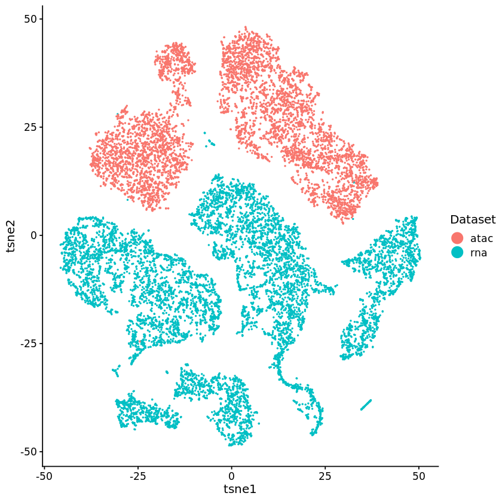

```r
int.pbmc <- runTSNE(int.pbmc, use.raw = T)
p1 <- plotByDatasetAndCluster(int.pbmc, return.plots = T)
print(p1[[1]])
```

- データセットをより良く統合するために、我々はquantile normalizationを実行する。
- このプロセスでは、まず、shared factor neighborhoodsに基づいて類似性グラフを構築することで、データセット間で類似した負荷を持つ細胞を識別する。
- 次に、Louvainコミュニティ検出を使用して、データセット間でクラスタを共同で識別し、各クラスタと因子内のquantileを正規化します。
- このステップの重要なパラメータは、`resolution`（これを上げるとクラスタ数が増えます）と`knn_k`（共有因子近傍を生成する際に使用されるデータセット近傍の数）です。
- 一般的に、`knn_k`を低くすることで、より小さなグループをより細かく識別することができますが、その代償としてデータセット間のアラインメントが低下する可能性があります。ここではデフォルト値（`resolution=1.0`と`knn_k=20`）を使用しています。

```r
options(warn=-1)
int.pbmc <- quantileAlignSNF(int.pbmc)
```

## Visualization

Now we can visualize the integrated data using t-SNE. (Note that liger also has a runUMAP function if you prefer UMAP and a FItSNE option for larger datasets.)

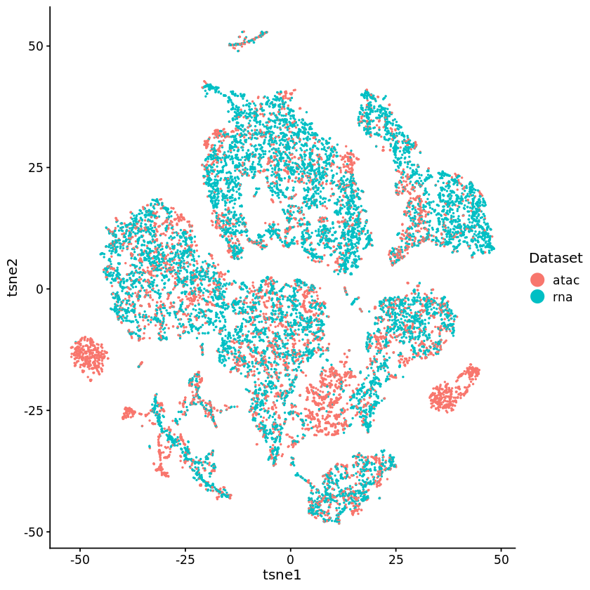

```r
int.pbmc <- runTSNE(int.pbmc)
plots <- plotByDatasetAndCluster(int.pbmc, return.plots = T,clusters=rna_clusts)
print(plots[[1]])
```

To see how the aligned space preserves the structure from the RNA data, we can plot the previously annotated cluster assignments for the RNA profiles:

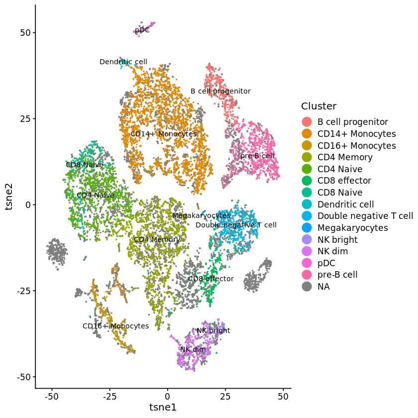

```r
print(plots[[2]])
```

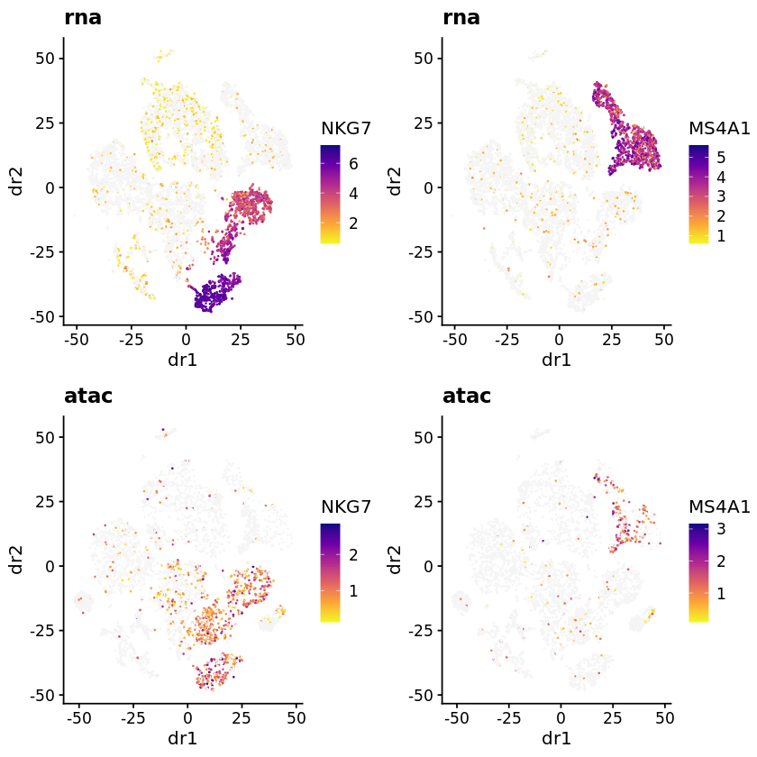

```r
# Plotting the expression and accessibility for NK and B-cell markers indicates that these cells are properly aligned.
NKG7 = plotGene(int.pbmc,gene="NKG7",return.plots=T)
MS4A1 = plotGene(int.pbmc,gene="MS4A1",return.plots=T)
plot_grid(NKG7[[2]],MS4A1[[2]],NKG7[[1]],MS4A1[[1]],ncol=2)
```

## (Optional) Calculate Gene-Level Features for ATAC Data

ここでは、10X `cellranger count` pipelineで出力された`fragments.tsv`ファイルから、gene x cell feature matrixを計算する方法を示します。Pre-Computed Count Matrices で単純にLIGERを試したい場合は、このセクションをスキップしてください。

- ATACデータから遺伝子レベルの特徴量を計算するための多くの戦略を想像することができますが、我々は、可能な限り最も単純な戦略がうまく機能することを発見しました：各遺伝子の遺伝子本体とプロモーターに重なるリードの数をカウントします。
- `cellranger count`で出力されたピークカウントを各遺伝子に重なるピークで合計する方法も有効であったが、この戦略は以下の点であまり好ましくない。
  - ピークに含まれないリードからの情報が失われること、
  - cellrangerのピーク呼び出しがすべての細胞に対して行われるため、豊富な細胞集団からのピークが過大に表現され、レアな細胞集団に対する偏りが生じること

cellrangerで出力されたフラグメントをバーコードでソートし、BEDOPSの`bedmap`を使用して、各遺伝子とプロモーターに重なるセルバーコードのリストを作成します。このステップを実行するには、[BEDOPS](https://bedops.readthedocs.io/en/latest/content/installation.html)をインストールする必要があります。ファイル `atac_fragments.tsv.gz` は、10X のウェブサイトの[このリンク](http://cf.10xgenomics.com/samples/cell-atac/1.1.0/atac_v1_pbmc_10k/atac_v1_pbmc_10k_fragments.tsv.gz)から入手できます。このファイルは非常に大きく、ファイルをソートするステップがやや遅いことに注意してください。

```r
#system("wget http://cf.10xgenomics.com/samples/cell-atac/1.1.0/atac_v1_pbmc_10k/atac_v1_pbmc_10k_fragments.tsv.gz")
```

```r
# bedmapを使ってatac_genes_bc.bed, atac_promoters_bc.bed を作成
system("zcat atac_v1_pbmc_10k_fragments.tsv.gz | sort -k4,4 > rna-atac/atac_fragments.sort.bed")
system("bedmap --delim \"\\t\" --echo --echo-map-id rna-atac/hg19_genes.bed rna-atac/atac_fragments.sort.bed > rna-atac/atac_genes_bc.bed")
system("bedmap --delim \"\\t\" --echo --echo-map-id rna-atac/hg19_promoters.bed rna-atac/atac_fragments.sort.bed > rna-atac/atac_promoters_bc.bed")
```

- `bedmap`の出力をRにインポートします。`read.table`の`as.is`パラメーターを使用して、遺伝子記号などの文字列の因子への変換を抑制していることに注意してください。
- Ligerの`makeFeatureMatrix`関数を使用して、遺伝子とプロモーターのアクセシビリティカウントを計算します。 最後に、これらの行列の行を遺伝子記号で並べ替えて追加します。
- 遺伝子とプロモーターのBEDファイルを組み合わせることで、これらの合計数を1つのステップで計算することもできます。 下流の分析に役立つかもしれないので、ここではそれらを別々に計算します。

```r
genes.bc <- read.table(file = "rna-atac/atac_genes_bc.bed", sep = "\t", as.is = c(4,7), header = FALSE)
promoters.bc <- read.table(file = "rna-atac/atac_promoters_bc.bed", sep = "\t", as.is = c(4,7), header = FALSE)
```

```r
#The makeFeatureMatrix function requires a list of barcodes as a vector
barcodes = names(atac_clusts)
gene.counts <- makeFeatureMatrix(genes.bc, barcodes)
promoter.counts <- makeFeatureMatrix(promoters.bc, barcodes)
gene.counts <- gene.counts[order(rownames(gene.counts)),]
promoter.counts <- promoter.counts[order(rownames(promoter.counts)),]
pbmc.atac <- gene.counts + promoter.counts
```

## (Optional) Read 10X RNA Output

```r
sample.dir = '.'
sample.name = 'pbmc.rna'
pbmc.rna <- read10X(sample.dirs = list(sample.dir), sample.names = list(sample.name))
```